# Risk Factor Analysis

## Outcome Variable

**Outcome Variable:** y_rate_len

## Predictor Variables

**Intervention Variable:** fhtcm

**Adjustment Set:**

unadjusted

## Stratifying Variables

The analysis was stratified on these variable(s):

- agecat
- studyid
- country

## Data Summary

| agecat | studyid | country | fhtcm | n_cell | n |
| --- | --- | --- | --- | --- | --- |
| 0-3 months | COHORTS | GUATEMALA | >=167 cm | 25 | 180 |
| 0-3 months | COHORTS | GUATEMALA | <162 cm | 106 | 180 |
| 0-3 months | COHORTS | GUATEMALA | [162-167) cm | 49 | 180 |
| 0-3 months | Keneba | GAMBIA | >=167 cm | 631 | 965 |
| 0-3 months | Keneba | GAMBIA | <162 cm | 75 | 965 |
| 0-3 months | Keneba | GAMBIA | [162-167) cm | 259 | 965 |
| 0-3 months | PROBIT | BELARUS | >=167 cm | 10775 | 11502 |
| 0-3 months | PROBIT | BELARUS | <162 cm | 151 | 11502 |
| 0-3 months | PROBIT | BELARUS | [162-167) cm | 576 | 11502 |
| 0-3 months | SAS-CompFeed | INDIA | >=167 cm | 345 | 765 |
| 0-3 months | SAS-CompFeed | INDIA | <162 cm | 196 | 765 |
| 0-3 months | SAS-CompFeed | INDIA | [162-167) cm | 224 | 765 |
| 3-6 months | COHORTS | GUATEMALA | >=167 cm | 37 | 261 |
| 3-6 months | COHORTS | GUATEMALA | <162 cm | 148 | 261 |
| 3-6 months | COHORTS | GUATEMALA | [162-167) cm | 76 | 261 |
| 3-6 months | Keneba | GAMBIA | >=167 cm | 673 | 1037 |
| 3-6 months | Keneba | GAMBIA | <162 cm | 74 | 1037 |
| 3-6 months | Keneba | GAMBIA | [162-167) cm | 290 | 1037 |
| 3-6 months | PROBIT | BELARUS | >=167 cm | 9472 | 10103 |
| 3-6 months | PROBIT | BELARUS | <162 cm | 129 | 10103 |
| 3-6 months | PROBIT | BELARUS | [162-167) cm | 502 | 10103 |
| 3-6 months | SAS-CompFeed | INDIA | >=167 cm | 308 | 682 |
| 3-6 months | SAS-CompFeed | INDIA | <162 cm | 175 | 682 |
| 3-6 months | SAS-CompFeed | INDIA | [162-167) cm | 199 | 682 |
| 6-9 months | COHORTS | GUATEMALA | >=167 cm | 39 | 308 |
| 6-9 months | COHORTS | GUATEMALA | <162 cm | 186 | 308 |
| 6-9 months | COHORTS | GUATEMALA | [162-167) cm | 83 | 308 |
| 6-9 months | Keneba | GAMBIA | >=167 cm | 442 | 663 |
| 6-9 months | Keneba | GAMBIA | <162 cm | 53 | 663 |
| 6-9 months | Keneba | GAMBIA | [162-167) cm | 168 | 663 |

[output cut: 72 more lines]

The following strata were considered:

- agecat: 0-3 months, studyid: COHORTS, country: GUATEMALA
- agecat: 0-3 months, studyid: Keneba, country: GAMBIA
- agecat: 0-3 months, studyid: PROBIT, country: BELARUS
- agecat: 0-3 months, studyid: SAS-CompFeed, country: INDIA
- agecat: 12-15 months, studyid: COHORTS, country: GUATEMALA
- agecat: 12-15 months, studyid: Keneba, country: GAMBIA
- agecat: 12-15 months, studyid: PROBIT, country: BELARUS
- agecat: 12-15 months, studyid: SAS-CompFeed, country: INDIA
- agecat: 12-15 months, studyid: SAS-FoodSuppl, country: INDIA
- agecat: 15-18 months, studyid: COHORTS, country: GUATEMALA
- agecat: 15-18 months, studyid: Keneba, country: GAMBIA
- agecat: 15-18 months, studyid: PROBIT, country: BELARUS
- agecat: 15-18 months, studyid: SAS-CompFeed, country: INDIA
- agecat: 15-18 months, studyid: SAS-FoodSuppl, country: INDIA
- agecat: 18-21 months, studyid: COHORTS, country: GUATEMALA
- agecat: 18-21 months, studyid: Keneba, country: GAMBIA
- agecat: 18-21 months, studyid: PROBIT, country: BELARUS
- agecat: 21-24 months, studyid: COHORTS, country: GUATEMALA
- agecat: 21-24 months, studyid: Keneba, country: GAMBIA
- agecat: 21-24 months, studyid: PROBIT, country: BELARUS
- agecat: 3-6 months, studyid: COHORTS, country: GUATEMALA
- agecat: 3-6 months, studyid: Keneba, country: GAMBIA
- agecat: 3-6 months, studyid: PROBIT, country: BELARUS
- agecat: 3-6 months, studyid: SAS-CompFeed, country: INDIA
- agecat: 6-9 months, studyid: COHORTS, country: GUATEMALA
- agecat: 6-9 months, studyid: Keneba, country: GAMBIA
- agecat: 6-9 months, studyid: PROBIT, country: BELARUS
- agecat: 6-9 months, studyid: SAS-CompFeed, country: INDIA
- agecat: 6-9 months, studyid: SAS-FoodSuppl, country: INDIA
- agecat: 9-12 months, studyid: COHORTS, country: GUATEMALA
- agecat: 9-12 months, studyid: Keneba, country: GAMBIA
- agecat: 9-12 months, studyid: PROBIT, country: BELARUS
- agecat: 9-12 months, studyid: SAS-CompFeed, country: INDIA
- agecat: 9-12 months, studyid: SAS-FoodSuppl, country: INDIA

### Dropped Strata

Some strata were dropped due to rare outcomes:

- agecat: 15-18 months, studyid: PROBIT, country: BELARUS
- agecat: 18-21 months, studyid: PROBIT, country: BELARUS
- agecat: 21-24 months, studyid: PROBIT, country: BELARUS

## Methods Detail

We’re interested in the causal parameters $E[Y_a]$ for all values of $a \in \mathcal{A}$. These parameters represent the mean outcome if, possibly contrary to fact, we intervened to set all units to have $A=a$. Under the randomization and positivity assumptions, these are identified by the statistical parameters $\psi_a=E_W[E_{Y|A,W}(Y|A=a,W)]$. In addition, we’re interested in the mean of $Y$, $E[Y]$ under no intervention (the observed mean). We will estimate these parameters by using SuperLearner to fit the relevant likelihood factors – $E_{Y|A,W}(Y|A=a,W)$ and $p(A=a|W)$, and then updating our likelihood fit using a joint TMLE.

For unadjusted analyses ($W=\{\}$), initial likelihoods were estimated using Lrnr_glm to estimate the simple $E(Y|A)$ and Lrnr_mean to estimate $p(A)$. For adjusted analyses, a small library containing Lrnr_glmnet, Lrnr_xgboost, and Lrnr_mean was used.

Having estimated these parameters, we will then use the delta method to estimate relative risks and attributable risks relative to a prespecified baseline level of $A$.

# Results Detail

## Results Plots

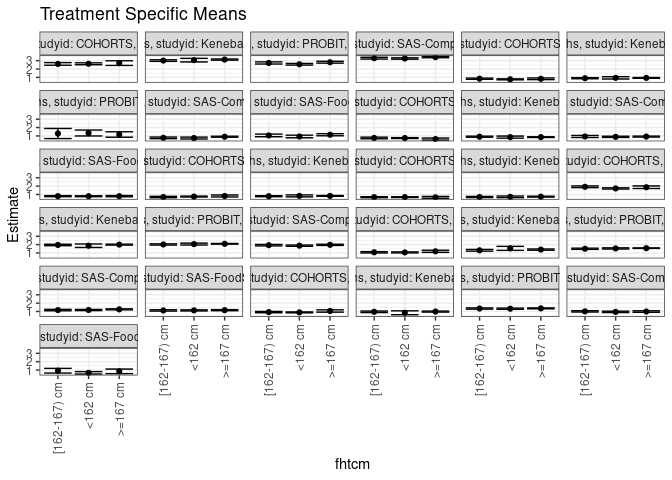

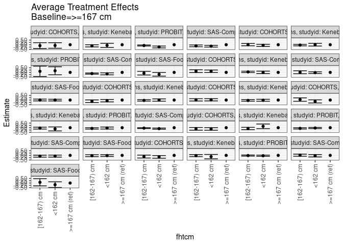

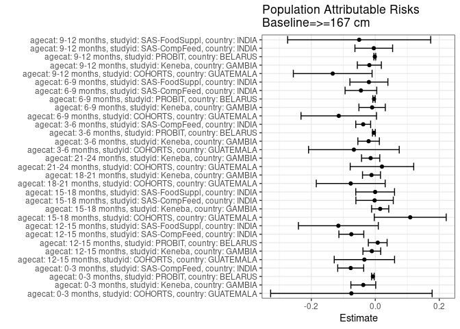

## Results Table

### Parameter: TSM

| agecat | studyid | country | intervention_level | baseline_level | estimate | ci_lower | ci_upper |
| --- | --- | --- | --- | --- | --- | --- | --- |
| 0-3 months | COHORTS | GUATEMALA | >=167 cm | NA | 2.7100945 | 2.4320732 | 2.9881158 |
| 0-3 months | COHORTS | GUATEMALA | <162 cm | NA | 2.6289035 | 2.5143166 | 2.7434903 |
| 0-3 months | COHORTS | GUATEMALA | [162-167) cm | NA | 2.6112386 | 2.4541916 | 2.7682855 |
| 0-3 months | Keneba | GAMBIA | >=167 cm | NA | 3.1319025 | 3.0628593 | 3.2009457 |
| 0-3 months | Keneba | GAMBIA | <162 cm | NA | 3.0615278 | 2.8487174 | 3.2743382 |
| 0-3 months | Keneba | GAMBIA | [162-167) cm | NA | 3.0126540 | 2.9174204 | 3.1078875 |
| 0-3 months | PROBIT | BELARUS | >=167 cm | NA | 2.8114802 | 2.7004843 | 2.9224762 |
| 0-3 months | PROBIT | BELARUS | <162 cm | NA | 2.5690811 | 2.4716054 | 2.6665568 |
| 0-3 months | PROBIT | BELARUS | [162-167) cm | NA | 2.7259642 | 2.5962755 | 2.8556530 |
| 0-3 months | SAS-CompFeed | INDIA | >=167 cm | NA | 3.4217578 | 3.3503420 | 3.4931735 |
| 0-3 months | SAS-CompFeed | INDIA | <162 cm | NA | 3.2613181 | 3.1844280 | 3.3382082 |
| 0-3 months | SAS-CompFeed | INDIA | [162-167) cm | NA | 3.2998200 | 3.1988823 | 3.4007577 |
| 3-6 months | COHORTS | GUATEMALA | >=167 cm | NA | 1.8648547 | 1.7108707 | 2.0188386 |
| 3-6 months | COHORTS | GUATEMALA | <162 cm | NA | 1.7205451 | 1.6495259 | 1.7915643 |
| 3-6 months | COHORTS | GUATEMALA | [162-167) cm | NA | 1.9162695 | 1.8141898 | 2.0183492 |
| 3-6 months | Keneba | GAMBIA | >=167 cm | NA | 2.0003581 | 1.9461897 | 2.0545264 |
| 3-6 months | Keneba | GAMBIA | <162 cm | NA | 1.8704267 | 1.6601132 | 2.0807401 |
| 3-6 months | Keneba | GAMBIA | [162-167) cm | NA | 1.9588819 | 1.8760217 | 2.0417421 |
| 3-6 months | PROBIT | BELARUS | >=167 cm | NA | 2.0960976 | 2.0550580 | 2.1371372 |
| 3-6 months | PROBIT | BELARUS | <162 cm | NA | 2.0625817 | 1.9480747 | 2.1770887 |
| 3-6 months | PROBIT | BELARUS | [162-167) cm | NA | 2.0180506 | 1.9434438 | 2.0926574 |
| 3-6 months | SAS-CompFeed | INDIA | >=167 cm | NA | 1.9759003 | 1.9057450 | 2.0460556 |
| 3-6 months | SAS-CompFeed | INDIA | <162 cm | NA | 1.8770998 | 1.8034484 | 1.9507513 |
| 3-6 months | SAS-CompFeed | INDIA | [162-167) cm | NA | 1.9332958 | 1.8486358 | 2.0179559 |
| 6-9 months | COHORTS | GUATEMALA | >=167 cm | NA | 1.2032980 | 1.0765829 | 1.3300132 |
| 6-9 months | COHORTS | GUATEMALA | <162 cm | NA | 1.0681606 | 1.0098967 | 1.1264245 |
| 6-9 months | COHORTS | GUATEMALA | [162-167) cm | NA | 1.0824850 | 1.0064342 | 1.1585358 |
| 6-9 months | Keneba | GAMBIA | >=167 cm | NA | 1.4065899 | 1.3319448 | 1.4812350 |
| 6-9 months | Keneba | GAMBIA | <162 cm | NA | 1.5537799 | 1.3145006 | 1.7930593 |
| 6-9 months | Keneba | GAMBIA | [162-167) cm | NA | 1.3210977 | 1.2169956 | 1.4251998 |

[output cut: 63 more lines]

### Parameter: E(Y)

| agecat | studyid | country | intervention_level | baseline_level | estimate | ci_lower | ci_upper |
| --- | --- | --- | --- | --- | --- | --- | --- |
| 0-3 months | COHORTS | GUATEMALA | NA | NA | 2.6353712 | 2.5465302 | 2.7242122 |
| 0-3 months | Keneba | GAMBIA | NA | NA | 3.0944274 | 3.0398727 | 3.1489822 |
| 0-3 months | PROBIT | BELARUS | NA | NA | 2.8040155 | 2.6922827 | 2.9157483 |
| 0-3 months | SAS-CompFeed | INDIA | NA | NA | 3.3449470 | 3.2851675 | 3.4047265 |
| 3-6 months | COHORTS | GUATEMALA | NA | NA | 1.7979953 | 1.7423030 | 1.8536877 |
| 3-6 months | Keneba | GAMBIA | NA | NA | 1.9794873 | 1.9347361 | 2.0242384 |
| 3-6 months | PROBIT | BELARUS | NA | NA | 2.0917916 | 2.0507260 | 2.1328572 |
| 3-6 months | SAS-CompFeed | INDIA | NA | NA | 1.9381168 | 1.8722991 | 2.0039344 |
| 6-9 months | COHORTS | GUATEMALA | NA | NA | 1.0891323 | 1.0450915 | 1.1331731 |
| 6-9 months | Keneba | GAMBIA | NA | NA | 1.3966930 | 1.3370412 | 1.4563449 |
| 6-9 months | PROBIT | BELARUS | NA | NA | 1.5711878 | 1.5417167 | 1.6006589 |
| 6-9 months | SAS-CompFeed | INDIA | NA | NA | 1.2144768 | 1.1795030 | 1.2494506 |
| 6-9 months | SAS-FoodSuppl | INDIA | NA | NA | 1.1405137 | 1.0997387 | 1.1812887 |
| 9-12 months | COHORTS | GUATEMALA | NA | NA | 0.9293038 | 0.8874492 | 0.9711585 |
| 9-12 months | Keneba | GAMBIA | NA | NA | 0.9708891 | 0.9222915 | 1.0194866 |
| 9-12 months | PROBIT | BELARUS | NA | NA | 1.3751690 | 1.3226496 | 1.4276884 |
| 9-12 months | SAS-CompFeed | INDIA | NA | NA | 0.9930838 | 0.9436059 | 1.0425616 |
| 9-12 months | SAS-FoodSuppl | INDIA | NA | NA | 0.7916715 | 0.6618281 | 0.9215150 |
| 12-15 months | COHORTS | GUATEMALA | NA | NA | 0.8018513 | 0.7601969 | 0.8435058 |
| 12-15 months | Keneba | GAMBIA | NA | NA | 0.9309324 | 0.8952046 | 0.9666602 |
| 12-15 months | PROBIT | BELARUS | NA | NA | 1.1801864 | 0.8594720 | 1.5009008 |
| 12-15 months | SAS-CompFeed | INDIA | NA | NA | 0.8285766 | 0.7562994 | 0.9008539 |
| 12-15 months | SAS-FoodSuppl | INDIA | NA | NA | 1.0258822 | 0.9363066 | 1.1154578 |
| 15-18 months | COHORTS | GUATEMALA | NA | NA | 0.7314958 | 0.6886307 | 0.7743608 |
| 15-18 months | Keneba | GAMBIA | NA | NA | 0.8726682 | 0.8384641 | 0.9068722 |
| 15-18 months | SAS-CompFeed | INDIA | NA | NA | 0.9190004 | 0.8846761 | 0.9533247 |
| 15-18 months | SAS-FoodSuppl | INDIA | NA | NA | 0.7935645 | 0.7577956 | 0.8293333 |
| 18-21 months | COHORTS | GUATEMALA | NA | NA | 0.7418707 | 0.7002233 | 0.7835182 |
| 18-21 months | Keneba | GAMBIA | NA | NA | 0.8178809 | 0.7819425 | 0.8538193 |
| 21-24 months | COHORTS | GUATEMALA | NA | NA | 0.6767187 | 0.6431305 | 0.7103068 |
| 21-24 months | Keneba | GAMBIA | NA | NA | 0.7242397 | 0.6859939 | 0.7624856 |

### Parameter: ATE

| agecat | studyid | country | intervention_level | baseline_level | estimate | ci_lower | ci_upper |
| --- | --- | --- | --- | --- | --- | --- | --- |
| 0-3 months | COHORTS | GUATEMALA | >=167 cm | >=167 cm | 0.0000000 | 0.0000000 | 0.0000000 |
| 0-3 months | COHORTS | GUATEMALA | <162 cm | >=167 cm | -0.0811911 | -0.3819002 | 0.2195180 |
| 0-3 months | COHORTS | GUATEMALA | [162-167) cm | >=167 cm | -0.0988560 | -0.4181671 | 0.2204551 |
| 0-3 months | Keneba | GAMBIA | >=167 cm | >=167 cm | 0.0000000 | 0.0000000 | 0.0000000 |
| 0-3 months | Keneba | GAMBIA | <162 cm | >=167 cm | -0.0703748 | -0.2941050 | 0.1533555 |
| 0-3 months | Keneba | GAMBIA | [162-167) cm | >=167 cm | -0.1192486 | -0.2368768 | -0.0016204 |
| 0-3 months | PROBIT | BELARUS | >=167 cm | >=167 cm | 0.0000000 | 0.0000000 | 0.0000000 |
| 0-3 months | PROBIT | BELARUS | <162 cm | >=167 cm | -0.2423991 | -0.3416466 | -0.1431517 |
| 0-3 months | PROBIT | BELARUS | [162-167) cm | >=167 cm | -0.0855160 | -0.1393427 | -0.0316893 |
| 0-3 months | SAS-CompFeed | INDIA | >=167 cm | >=167 cm | 0.0000000 | 0.0000000 | 0.0000000 |
| 0-3 months | SAS-CompFeed | INDIA | <162 cm | >=167 cm | -0.1604397 | -0.2548697 | -0.0660097 |
| 0-3 months | SAS-CompFeed | INDIA | [162-167) cm | >=167 cm | -0.1219378 | -0.2177827 | -0.0260928 |
| 3-6 months | COHORTS | GUATEMALA | >=167 cm | >=167 cm | 0.0000000 | 0.0000000 | 0.0000000 |
| 3-6 months | COHORTS | GUATEMALA | <162 cm | >=167 cm | -0.1443095 | -0.3138819 | 0.0252628 |
| 3-6 months | COHORTS | GUATEMALA | [162-167) cm | >=167 cm | 0.0514148 | -0.1333318 | 0.2361615 |
| 3-6 months | Keneba | GAMBIA | >=167 cm | >=167 cm | 0.0000000 | 0.0000000 | 0.0000000 |
| 3-6 months | Keneba | GAMBIA | <162 cm | >=167 cm | -0.1299314 | -0.3471086 | 0.0872459 |
| 3-6 months | Keneba | GAMBIA | [162-167) cm | >=167 cm | -0.0414761 | -0.1404712 | 0.0575189 |
| 3-6 months | PROBIT | BELARUS | >=167 cm | >=167 cm | 0.0000000 | 0.0000000 | 0.0000000 |
| 3-6 months | PROBIT | BELARUS | <162 cm | >=167 cm | -0.0335159 | -0.1415876 | 0.0745557 |
| 3-6 months | PROBIT | BELARUS | [162-167) cm | >=167 cm | -0.0780470 | -0.1499207 | -0.0061733 |
| 3-6 months | SAS-CompFeed | INDIA | >=167 cm | >=167 cm | 0.0000000 | 0.0000000 | 0.0000000 |
| 3-6 months | SAS-CompFeed | INDIA | <162 cm | >=167 cm | -0.0988005 | -0.1618544 | -0.0357465 |
| 3-6 months | SAS-CompFeed | INDIA | [162-167) cm | >=167 cm | -0.0426045 | -0.0879008 | 0.0026919 |
| 6-9 months | COHORTS | GUATEMALA | >=167 cm | >=167 cm | 0.0000000 | 0.0000000 | 0.0000000 |
| 6-9 months | COHORTS | GUATEMALA | <162 cm | >=167 cm | -0.1351374 | -0.2746057 | 0.0043309 |
| 6-9 months | COHORTS | GUATEMALA | [162-167) cm | >=167 cm | -0.1208131 | -0.2685982 | 0.0269721 |
| 6-9 months | Keneba | GAMBIA | >=167 cm | >=167 cm | 0.0000000 | 0.0000000 | 0.0000000 |
| 6-9 months | Keneba | GAMBIA | <162 cm | >=167 cm | 0.1471900 | -0.1034621 | 0.3978422 |
| 6-9 months | Keneba | GAMBIA | [162-167) cm | >=167 cm | -0.0854922 | -0.2135904 | 0.0426060 |

[output cut: 63 more lines]

### Parameter: PAR

| agecat | studyid | country | intervention_level | baseline_level | estimate | ci_lower | ci_upper |
| --- | --- | --- | --- | --- | --- | --- | --- |
| 0-3 months | COHORTS | GUATEMALA | >=167 cm | NA | -0.0747233 | -0.3271466 | 0.1776999 |
| 0-3 months | Keneba | GAMBIA | >=167 cm | NA | -0.0374751 | -0.0763220 | 0.0013718 |
| 0-3 months | PROBIT | BELARUS | >=167 cm | NA | -0.0074647 | -0.0114735 | -0.0034560 |
| 0-3 months | SAS-CompFeed | INDIA | >=167 cm | NA | -0.0768108 | -0.1174469 | -0.0361746 |
| 3-6 months | COHORTS | GUATEMALA | >=167 cm | NA | -0.0668593 | -0.2085986 | 0.0748799 |
| 3-6 months | Keneba | GAMBIA | >=167 cm | NA | -0.0208708 | -0.0544616 | 0.0127200 |
| 3-6 months | PROBIT | BELARUS | >=167 cm | NA | -0.0043060 | -0.0087463 | 0.0001344 |
| 3-6 months | SAS-CompFeed | INDIA | >=167 cm | NA | -0.0377835 | -0.0610356 | -0.0145314 |
| 6-9 months | COHORTS | GUATEMALA | >=167 cm | NA | -0.1141657 | -0.2321911 | 0.0038597 |
| 6-9 months | Keneba | GAMBIA | >=167 cm | NA | -0.0098969 | -0.0511406 | 0.0313469 |
| 6-9 months | PROBIT | BELARUS | >=167 cm | NA | -0.0039562 | -0.0076115 | -0.0003009 |
| 6-9 months | SAS-CompFeed | INDIA | >=167 cm | NA | -0.0449076 | -0.0944349 | 0.0046197 |
| 6-9 months | SAS-FoodSuppl | INDIA | >=167 cm | NA | -0.0199874 | -0.0793615 | 0.0393868 |
| 9-12 months | COHORTS | GUATEMALA | >=167 cm | NA | -0.1330851 | -0.2561834 | -0.0099868 |
| 9-12 months | Keneba | GAMBIA | >=167 cm | NA | -0.0185846 | -0.0561088 | 0.0189396 |
| 9-12 months | PROBIT | BELARUS | >=167 cm | NA | -0.0014762 | -0.0042902 | 0.0013378 |
| 9-12 months | SAS-CompFeed | INDIA | >=167 cm | NA | -0.0047245 | -0.0636231 | 0.0541740 |
| 9-12 months | SAS-FoodSuppl | INDIA | >=167 cm | NA | -0.0503373 | -0.2739659 | 0.1732912 |
| 12-15 months | COHORTS | GUATEMALA | >=167 cm | NA | -0.0340465 | -0.1283553 | 0.0602623 |
| 12-15 months | Keneba | GAMBIA | >=167 cm | NA | -0.0108070 | -0.0385798 | 0.0169658 |
| 12-15 months | PROBIT | BELARUS | >=167 cm | NA | 0.0076338 | -0.0216943 | 0.0369618 |
| 12-15 months | SAS-CompFeed | INDIA | >=167 cm | NA | -0.0748614 | -0.1138162 | -0.0359067 |
| 12-15 months | SAS-FoodSuppl | INDIA | >=167 cm | NA | -0.1154527 | -0.2402951 | 0.0093898 |
| 15-18 months | COHORTS | GUATEMALA | >=167 cm | NA | 0.1092229 | -0.0032877 | 0.2217335 |
| 15-18 months | Keneba | GAMBIA | >=167 cm | NA | 0.0153091 | -0.0114621 | 0.0420803 |
| 15-18 months | SAS-CompFeed | INDIA | >=167 cm | NA | -0.0021884 | -0.0606552 | 0.0562784 |
| 15-18 months | SAS-FoodSuppl | INDIA | >=167 cm | NA | -0.0003993 | -0.0609916 | 0.0601930 |
| 18-21 months | COHORTS | GUATEMALA | >=167 cm | NA | -0.0767127 | -0.1843836 | 0.0309581 |
| 18-21 months | Keneba | GAMBIA | >=167 cm | NA | -0.0118564 | -0.0399481 | 0.0162353 |
| 21-24 months | COHORTS | GUATEMALA | >=167 cm | NA | 0.0208676 | -0.0784091 | 0.1201444 |
| 21-24 months | Keneba | GAMBIA | >=167 cm | NA | -0.0144538 | -0.0429285 | 0.0140208 |